## STATS 762: Assignment 3

### Author: Tarin Eccleston

#### Rental bikes are introduced in many urban cities for the enhancement of mobility comfort. It is important to make the rental bike available and accessible to the public at the right time. In order to provide the city with a stable supply

of rental bikes, a reliable model for rented bike counts at each hour and weather is required. The spreadsheet SeoulBikeSpring.csv contains rented bike counts at each hour and weather information in Seoul, Korea.

```r
library(tidyverse)
```

```r
library(ggplot2)
library(glmnet)
library(pscl)
library(quantreg)
setwd("/Users/tarineccleston/Documents/Masters/STATS 762/regression-for-DS/seoul-bike-spring")

seoul_bike_df = as.data.frame(read.csv("data/SeoulBikeSpring.csv"))
next_day_df = as.data.frame(read.csv("data/nextday.csv"))

set.seed(991)
```

#### 1a) Why snowfall is not useful in modelling rented bike counts and there is no need to include snowfall in a model?

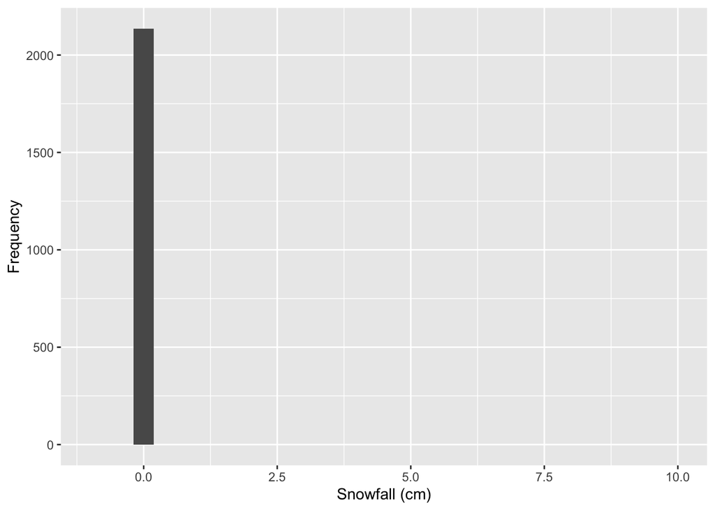

```r
ggplot(seoul_bike_df, aes(x = Snowfall)) +
  geom_histogram() +
  labs(x = "Snowfall (cm)", y = "Frequency") +
  xlim(-1, 10)
```

ALL 2136 observations in Spring record 0 cm of snowfall in that particular hour. In regression we are interested in changes of an explanatory variable and it’s effect on the response variable. If the values of the snowfall have no variation for all observations, then it is recommend to remove snowfall as it doesn’t provide any information and may negatively impact the model’s performance.

#### 1b) it an appropriate regression model using all covariates except snow-fall and, find the mean squared error (MSE).

```r
# remove snowfall
seoul_bike_df = subset(seoul_bike_df, select = -c(Snowfall))

# fit poisson model as we are trying to count the number of rented bikes
# include polynomial terms
seoul_bike_fit = glm(Rented.Bike.Count ~ ., family = "poisson", data = seoul_bike_df)
summary(seoul_bike_fit)
```

```
##
## Call:
## glm(formula = Rented.Bike.Count ~ ., family = "poisson", data = seoul_bike_df)
##
## Deviance Residuals:
##     Min       1Q   Median       3Q      Max
## -51.582  -10.262   -2.223    6.383   91.886
##
## Coefficients:
##                         Estimate Std. Error  z value Pr(>|z|)
## (Intercept)            5.686e+00  9.347e-03  608.303  < 2e-16 ***
## Hour                   4.543e-02  1.458e-04  311.493  < 2e-16 ***
## Temperature            4.923e-02  3.620e-04  136.009  < 2e-16 ***
## Humidity              -1.009e-02  1.047e-04  -96.366  < 2e-16 ***
## Wind.speed            -2.473e-03  8.301e-04   -2.979  0.00289 **
## Visibility             1.286e-04  1.636e-06   78.565  < 2e-16 ***
## Dew.point.temperature  1.020e-02  3.595e-04   28.381  < 2e-16 ***
## Solar.Radiation       -2.656e-02  1.028e-03  -25.842  < 2e-16 ***
## Rainfall              -8.745e-01  5.613e-03 -155.804  < 2e-16 ***
## ---
## Signif. codes:  0 '***' 0.001 '**' 0.01 '*' 0.05 '.' 0.1 ' ' 1
##
## (Dispersion parameter for poisson family taken to be 1)
##
##     Null deviance: 1138924  on 2135  degrees of freedom
## Residual deviance:  468063  on 2127  degrees of freedom
## AIC: 484655
##
## Number of Fisher Scoring iterations: 7
```

All covariates appears to be significant.

```r
# Use the fitted model to predict the response variable for the testing data
y_hat = predict(seoul_bike_fit, newdata = seoul_bike_df, type = "response")

# Calculate the MSE for the predicted values
mse = mean((seoul_bike_df$Rented.Bike.Count - y_hat)^2)
mse
```

```
## [1] 149961.4
```

#### 1c) Fit a parsimonious regression with l1 penalty. List covariates included in the parsimonious model and find the MSE.

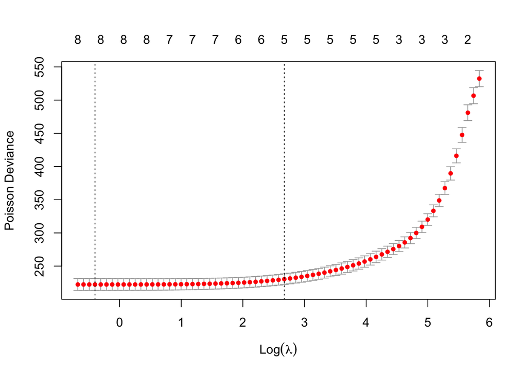

```r
# use CV on a range of lambda values for lasso regression
cv_lasso = cv.glmnet(as.matrix(seoul_bike_df[,-1]), as.matrix(seoul_bike_df[,1]), alpha=1 , family = "poisson", standardize=TRUE)
plot(cv_lasso)
```

```r
lamda_par = cv_lasso$lambda.1se
lamda_par
```

```
## [1] 14.46771
```

```r
coef(cv_lasso, s= cv_lasso$lambda.1se)
```

```
## 9 x 1 sparse Matrix of class "dgCMatrix"
##                                  s1
## (Intercept)            5.5623207793
## Hour                   0.0427984118
## Temperature            0.0533225347
## Humidity              -0.0077115127
## Wind.speed             .
## Visibility             0.0001116969
## Dew.point.temperature  .
## Solar.Radiation        .
## Rainfall              -0.3137970544
```

Since we use lasso regression, we get a mixture of shrinkage and sparsity of beta coefficients. Therefore we perform variable selection. The included covariates are: Hour, Temperature, Humidity, Visibility and Rainfall.

```r
y_hat_par = predict(cv_lasso, newx = as.matrix(seoul_bike_df[,-1]), s = lamda_par, type = "response")

# Calculate the MSE for the predicted values
mse_par <- mean((seoul_bike_df$Rented.Bike.Count - y_hat_par)^2)
mse_par
```

```
## [1] 157977.2
```

#### 1d) Using your parsimonious model in (c), predict rented bike counts

on the next day (nextday.csv). List your prediction against actual counts on the next day and find at which hour, your prediction is the best.

```r
next_day_df = subset(next_day_df, select = -c(Snowfall))

# use parsimonious model with l1 regularization
next_day_y_hat = predict(cv_lasso, newx = as.matrix(next_day_df[,-1]), s = lamda_par, type = "response")
colnames(next_day_y_hat) = "next_day_y_hat"

mse =  mean((next_day_df$Rented.Bike.Count - next_day_y_hat)^2)
mse
```

```
## [1] 310727.5
```

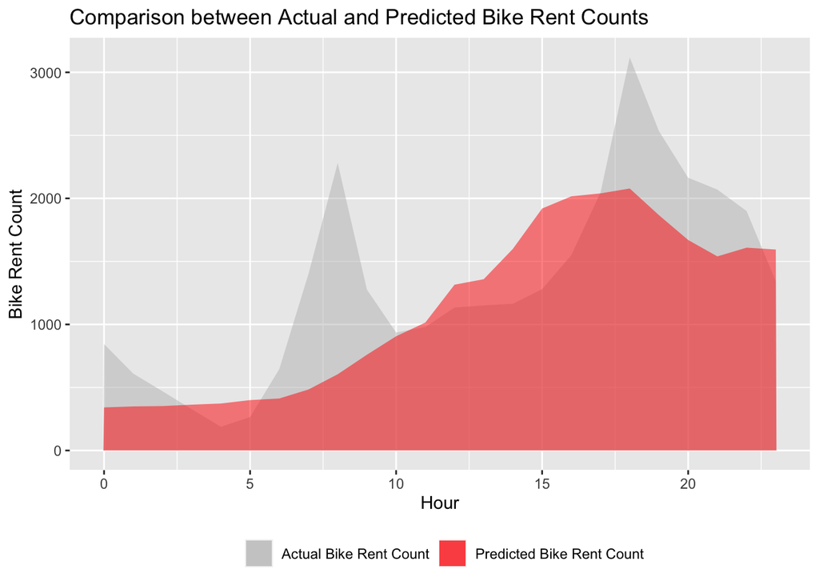

```r
# combine dataframes for plotting
next_day_y = as.data.frame(next_day_df$Rented.Bike.Count)
colnames(next_day_y) = "next_day_y"
next_day_y_hat = as.data.frame(next_day_y_hat)

next_day_comparisons = next_day_y %>%
  mutate(next_day_y_hat) %>%
  mutate(Hour = next_day_df$Hour) %>%
  relocate(Hour, .before = next_day_y)

ggplot(next_day_comparisons, aes(x = Hour)) +
  geom_area(aes(y = next_day_y, fill = "Actual Bike Rent Count"), alpha = 0.5) +
  geom_area(aes(y = next_day_y_hat, fill = "Predicted Bike Rent Count"), alpha = 0.5) +
  labs(x = "Hour", y = "Bike Rent Count", fill = "", color = "") +
  ggtitle("Comparison between Actual and Predicted Bike Rent Counts") +
  scale_fill_manual(name = "", values = c("Actual Bike Rent Count" = "grey", "Predicted Bike Rent Count" = "red")) +
  scale_color_manual(name = "", values = c("Actual Bike Rent Count" = "black", "Predicted Bike Rent Count" = "black")) +
  theme(legend.position = "bottom")
```

##### Normalize accuracy to get a percentage error

```r
next_day_comparisons = next_day_comparisons %>%
  mutate(error_percent = abs(next_day_y - next_day_y_hat)/next_day_y)
```

##### Plot Error Percentage

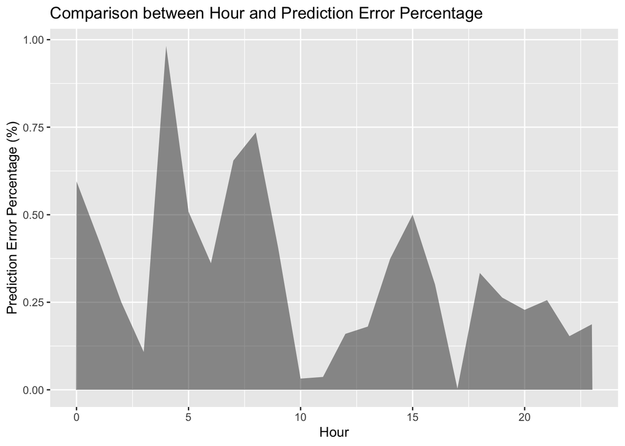

```r
ggplot(next_day_comparisons, aes(x = Hour)) +
  geom_area(aes(y = error_percent), alpha = 0.5) +
  labs(x = "Hour", y = "Prediction Error Percentage (%)", fill = "", color = "") +
  ggtitle("Comparison between Hour and Prediction Error Percentage")
```

```r
most_accurate_hour = next_day_comparisons$Hour[which.min(next_day_comparisons$error_percent)]
most_accurate_hour
```

```
## [1] 17
```

The predicted bike rent count appears to be most accurate at 5 pm. However since we are discreting the data, the final answer will be 5 pm - 6 pm.

#### 1e) Your friend claimed that there might be excess zero counts in particular hours or weather conditions and, it is worth to consider a more robust model. Using the same selection of covariates as in your parsimonious model in (c), validate your friend’s claim and describe how covariates affect rented bike counts. When you fit a more robust model for excess zeros, you will need to standardized covariates.

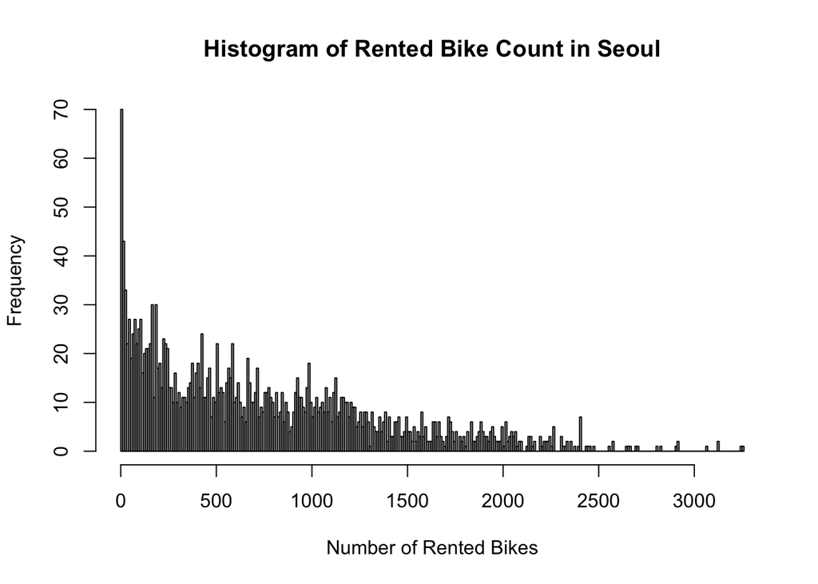

```r
# create data frame here
model_comparisons = data.frame(matrix(nrow = 3, ncol = 2))

# use variables from the parsimonious model
seoul_bike_df = subset(seoul_bike_df, select = -c(Wind.speed, Dew.point.temperature, Solar.Radiation))

# plot counts
hist(seoul_bike_df$Rented.Bike.Count, breaks = seq(min(seoul_bike_df$Rented.Bike.Count), max(seoul_bike_df$Rented.Bike.Count) + 10, by = 10),
     xlab = "Number of Rented Bikes", main = "Histogram of Rented Bike Count in Seoul")
```

There appears to be a clear inflation of zeros. I intend to use the hurdle model to account for zero-inflated data as we are only getting the inflated zeros from one source (covariates). Always good to compare with zero-inflated poisson and standard poisson

##### Poisson

```r
# standardize covariates
seoul_bike_df[,-1] = scale(seoul_bike_df[,-1])

seoul_bike_poisson_fit = glm(Rented.Bike.Count ~ ., data = seoul_bike_df, family = 'poisson')

# Calculate the MSE for the predicted values
y_hat_poisson = predict(seoul_bike_poisson_fit, newx = as.matrix(seoul_bike_df[,-1]), type = "response")
mse_poisson = mean((seoul_bike_df$Rented.Bike.Count - y_hat_poisson)^2)
model_comparisons[1,1] = mse_poisson
AIC_poisson = AIC(seoul_bike_poisson_fit)
model_comparisons[1,2] = AIC_poisson
summary(seoul_bike_poisson_fit)
```

```
##
## Call:
## glm(formula = Rented.Bike.Count ~ ., family = "poisson", data = seoul_bike_df)
##
## Deviance Residuals:
##     Min       1Q   Median       3Q      Max
## -52.090  -10.452   -2.378    6.529   92.696
##
## Coefficients:
##               Estimate Std. Error z value Pr(>|z|)
## (Intercept)  6.2740323  0.0013223 4744.71   <2e-16 ***
## Hour         0.3186502  0.0009380  339.70   <2e-16 ***
## Temperature  0.3622247  0.0008915  406.30   <2e-16 ***
## Humidity    -0.1493722  0.0010968 -136.19   <2e-16 ***
## Visibility   0.0833499  0.0010384   80.27   <2e-16 ***
## Rainfall    -1.0853644  0.0068599 -158.22   <2e-16 ***
## ---
## Signif. codes:  0 '***' 0.001 '**' 0.01 '*' 0.05 '.' 0.1 ' ' 1
##
## (Dispersion parameter for poisson family taken to be 1)
##
##     Null deviance: 1138924  on 2135  degrees of freedom
## Residual deviance:  470155  on 2130  degrees of freedom
## AIC: 486741
##
## Number of Fisher Scoring iterations: 7
```

##### Zero-Inflated Poisson

```r
seoul_bike_zinf_fit <- zeroinfl(Rented.Bike.Count ~ ., data = seoul_bike_df, dist='poisson')
# Calculate the MSE for the predicted values
y_hat_zinf = predict(seoul_bike_zinf_fit, newx = as.matrix(seoul_bike_df[,-1]), type = "response")
mse_zinf = mean((seoul_bike_df$Rented.Bike.Count - y_hat_zinf)^2)
model_comparisons[2,1] = mse_zinf
AIC_zinf = AIC(seoul_bike_zinf_fit)
model_comparisons[2,2] = AIC_zinf
summary(seoul_bike_zinf_fit)
```

```
##
## Call:
## zeroinfl(formula = Rented.Bike.Count ~ ., data = seoul_bike_df, dist = "poisson")
##
## Pearson residuals:
##        Min         1Q     Median         3Q        Max
## -2.583e+01 -2.687e+00 -5.505e-01  1.593e+00  4.437e+07
##
## Count model coefficients (poisson with log link):
##               Estimate Std. Error z value Pr(>|z|)
## (Intercept)  6.2962651  0.0013257 4749.45   <2e-16 ***
## Hour         0.3187594  0.0009372  340.13   <2e-16 ***
## Temperature  0.3579308  0.0008840  404.92   <2e-16 ***
## Humidity    -0.1491846  0.0010909 -136.75   <2e-16 ***
## Visibility   0.0808853  0.0010308   78.47   <2e-16 ***
## Rainfall    -1.1122254  0.0069092 -160.98   <2e-16 ***
##
## Zero-inflation model coefficients (binomial with logit link):
##               Estimate Std. Error z value Pr(>|z|)
## (Intercept) -2.934e+01  2.538e+03  -0.012    0.991
## Hour        -2.051e-02  1.549e-01  -0.132    0.895
## Temperature  2.278e-01  1.600e-01   1.424    0.154
## Humidity     2.468e-01  1.985e-01   1.243    0.214
## Visibility  -6.914e-03  1.766e-01  -0.039    0.969
## Rainfall    -1.658e+02  1.640e+04  -0.010    0.992
## ---
## Signif. codes:  0 '***' 0.001 '**' 0.01 '*' 0.05 '.' 0.1 ' ' 1
##
## Number of iterations in BFGS optimization: 48
## Log-likelihood: -2.071e+05 on 12 Df
```

##### Hurdle

```r
seoul_bike_hurdle_fit = hurdle(Rented.Bike.Count ~ ., data = seoul_bike_df, dist = 'poisson', link = 'logit')

# Calculate the MSE and AIC for the predicted values
y_hat_hurdle = predict(seoul_bike_hurdle_fit, newx = as.matrix(seoul_bike_df[,-1]), type = "response")
mse_hurdle = mean((seoul_bike_df$Rented.Bike.Count - y_hat_hurdle)^2)
model_comparisons[3,1] = mse_hurdle
AIC_hurdle = AIC(seoul_bike_hurdle_fit)
model_comparisons[3,2] = AIC_hurdle
summary(seoul_bike_hurdle_fit)
```

```
##
## Call:
## hurdle(formula = Rented.Bike.Count ~ ., data = seoul_bike_df, dist = "poisson",
##     link = "logit")
##
## Pearson residuals:
##        Min         1Q     Median         3Q        Max
## -2.581e+01 -2.681e+00 -5.512e-01  1.592e+00  6.761e+07
##
## Count model coefficients (truncated poisson with log link):
##               Estimate Std. Error z value Pr(>|z|)
## (Intercept)  6.2955130  0.0013297 4734.49   <2e-16 ***
## Hour         0.3187814  0.0009372  340.15   <2e-16 ***
## Temperature  0.3579551  0.0008840  404.95   <2e-16 ***
## Humidity    -0.1490496  0.0010910 -136.62   <2e-16 ***
## Visibility   0.0808591  0.0010308   78.44   <2e-16 ***
## Rainfall    -1.1179176  0.0069465 -160.93   <2e-16 ***
## Zero hurdle model coefficients (binomial with logit link):
##               Estimate Std. Error z value Pr(>|z|)
## (Intercept)  2.934e+01  2.538e+03   0.012    0.991
## Hour         2.051e-02  1.549e-01   0.132    0.895
## Temperature -2.278e-01  1.600e-01  -1.424    0.154
## Humidity    -2.468e-01  1.985e-01  -1.243    0.214
## Visibility   6.914e-03  1.766e-01   0.039    0.969
## Rainfall     1.658e+02  1.639e+04   0.010    0.992
## ---
## Signif. codes:  0 '***' 0.001 '**' 0.01 '*' 0.05 '.' 0.1 ' ' 1
##
## Number of iterations in BFGS optimization: 10
## Log-likelihood: -2.071e+05 on 12 Df
```

```r
colnames(model_comparisons) = c("MSE", "AIC")
rownames(model_comparisons) = c("Poisson", "Zero-inflated Poisson", "Hurdle")

model_comparisons
```

```
##                            MSE      AIC
## Poisson               151861.3 486740.9
## Zero-inflated Poisson 152124.2 414319.9
## Hurdle                152099.9 414185.7
```

I compared poisson, zero-inflated poisson and hurdle models, particularly their mse and AIC scores. Poisson had the lowest mse score, followed by Hurdle then zero-inflated poisson. For AIC, Poisson had the highest value, followed by zero-inflated poisson then hurdle. Hurdle had an AIC score 135 less than zero-inflated poisson, which is significant, indicating that it’s the model with the best fit to the data. We cannot rely on mse and AIC alone to chose the right model, despite hurdle having a higher mse than poisson, it is probably a better fit to our data.

Additionally, hurdle appears to be the most appropriate model given the context - we only have zeros rental bike counts from one source. Using the hurdle model would be the best in choice compared to the poisson and zero-inflated poisson models as we can appropriately account for the zero-inflation. It is also important to note that the AIC value for hurle is still high, however we are making a relative comparison in this case.

The spreadsheet SeoulBikeSpring.csv excluding bike counts is the hourly weather record in Seoul. We now wish to model the temperature with other weather information and hour. For Question 2, the rented bike counts is excluded.

#### 2a) Is snowfall still not useful in modelling temperature?

```r
seoul_spring_weather_df = as.data.frame(read.csv("data/SeoulBikeSpring.csv"))

# reorganise weather dataframe
seoul_spring_weather_df = seoul_spring_weather_df[,-1]
seoul_spring_weather_df = seoul_spring_weather_df %>%
  relocate(Temperature, .before = "Hour")
```

#### We are now modelling temperature. Even though temperature is much more related to snowfall due to physical relationships between them, it is still recommended to remove snowfall as it has no variation, i.e., all the values for that variable are the same, as they do not provide any information and may negatively impact the model’s performance.

#### 2b) Fit a parsimonious regression with l1 penalty. List covariates included in the parsimonious model and find the MSE.

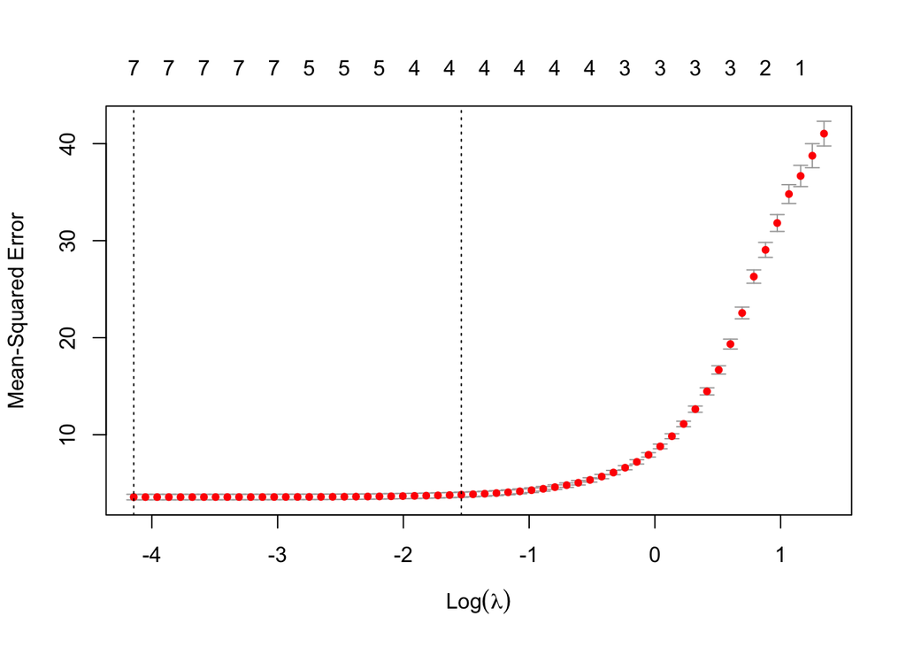

```r
seoul_spring_weather_df = subset(seoul_spring_weather_df, select = -c(Snowfall))

# use CV on a range of lambda values for lasso regression
cv_lasso = cv.glmnet(as.matrix(seoul_spring_weather_df[,-1]), as.matrix(seoul_spring_weather_df[,1]), family = 'gaussian', alpha=1, standardize=TRUE)
plot(cv_lasso)
```

```r
lamda_par = cv_lasso$lambda.1se
lamda_par
```

```
## [1] 0.2145635
```

```r
coef(cv_lasso, s= cv_lasso$lambda.1se)
```

```
## 8 x 1 sparse Matrix of class "dgCMatrix"
##                               s1
## (Intercept)           20.3750246
## Hour                   0.0288392
## Humidity              -0.2035285
## Wind.speed             .
## Visibility             .
## Dew.point.temperature  0.8962036
## Solar.Radiation        0.8865571
## Rainfall               .
```

Since we use lasso regression, we get a mixture of shrinkage and sparsity of beta coefficients. Therefore we perform variable selection. The included covariates are: Hour, Humidity, Dew.point.temperature and Solar.Radiation.

```r
y_hat_par = predict(cv_lasso, newx = as.matrix(seoul_spring_weather_df[,-1]), s = lamda_par, type = "response")

# Calculate the MSE for the predicted values
mse_par <- mean((seoul_spring_weather_df$Temperature - y_hat_par)^2)
mse_par
```

```
## [1] 3.777341
```

#### 2c) Using the same selection of covariates as in your parsimonious model

in (b), fit quantile regressions for median and lower/upper quartile temperatures. Present boxplot of median and lower/upper quartile temperatures against hours. Describe the two points in the relation between covariates and conditional distribution for temperature.

```r
# models for median and quartiles
q25 = rq(Temperature ~ Hour + Humidity + Dew.point.temperature + Solar.Radiation, data = seoul_spring_weather_df, tau = 0.25)
q25_pred = predict(q25, newdata = seoul_spring_weather_df, type='response')

q50 = rq(Temperature ~ Hour + Humidity + Dew.point.temperature + Solar.Radiation, data = seoul_spring_weather_df, tau = 0.50)
q50_pred = predict(q50, newdata = seoul_spring_weather_df, type='response')

q75 = rq(Temperature ~ Hour + Humidity + Dew.point.temperature + Solar.Radiation, data = seoul_spring_weather_df, tau = 0.75)
q75_pred = predict(q75, newdata = seoul_spring_weather_df, type='response')
```

##### Boxplots for Each Quantile

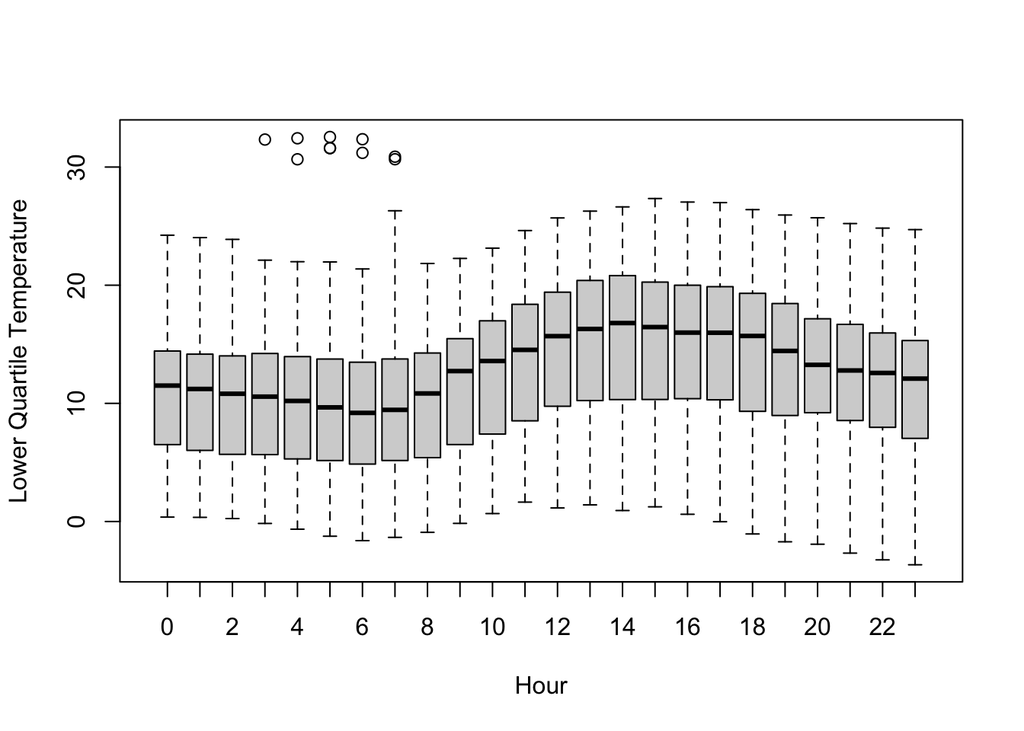

```r
plot_df = data.frame(Hour = seoul_spring_weather_df$Hour, q25_pred, q50_pred, q75_pred)
boxplot(q25_pred ~ Hour, data = plot_df, xlab = "Hour", ylab = "Lower Quartile Temperature")
```

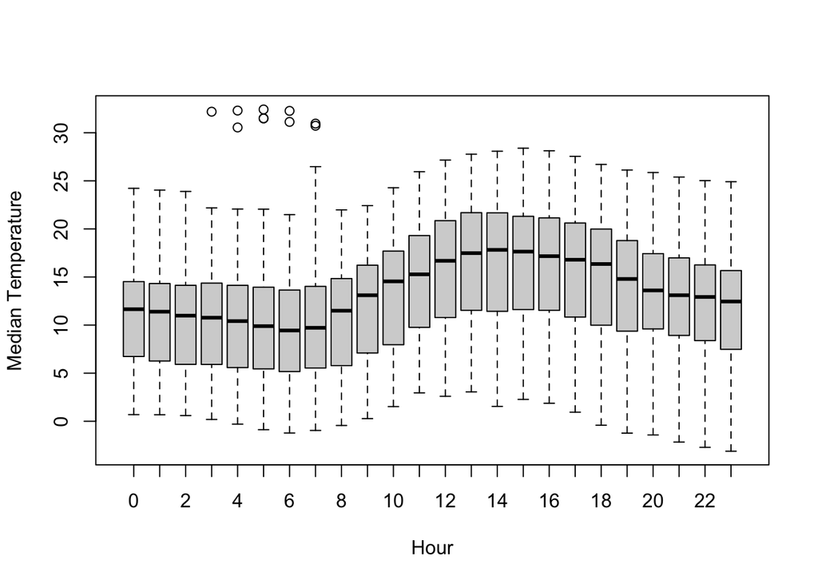

```r
boxplot(q50_pred ~ Hour, data = plot_df, xlab = "Hour", ylab = "Median Temperature")
```

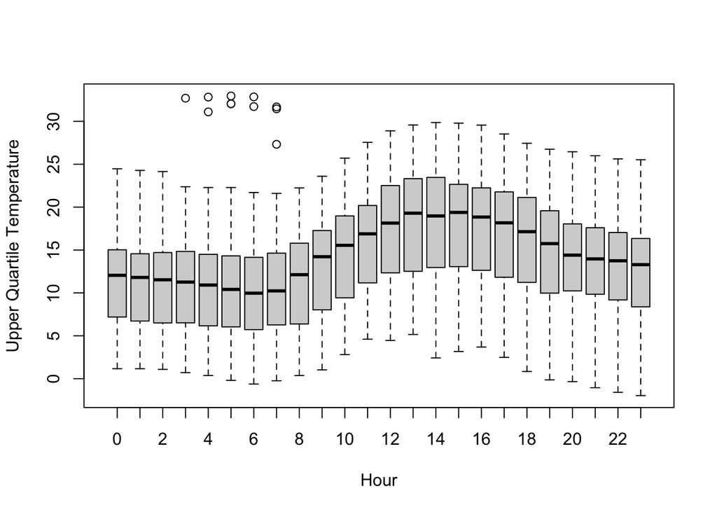

```r
boxplot(q75_pred ~ Hour, data = plot_df, xlab = "Hour", ylab = "Upper Quartile Temperature")
```

##### Boxplot for All Quantiles Combined

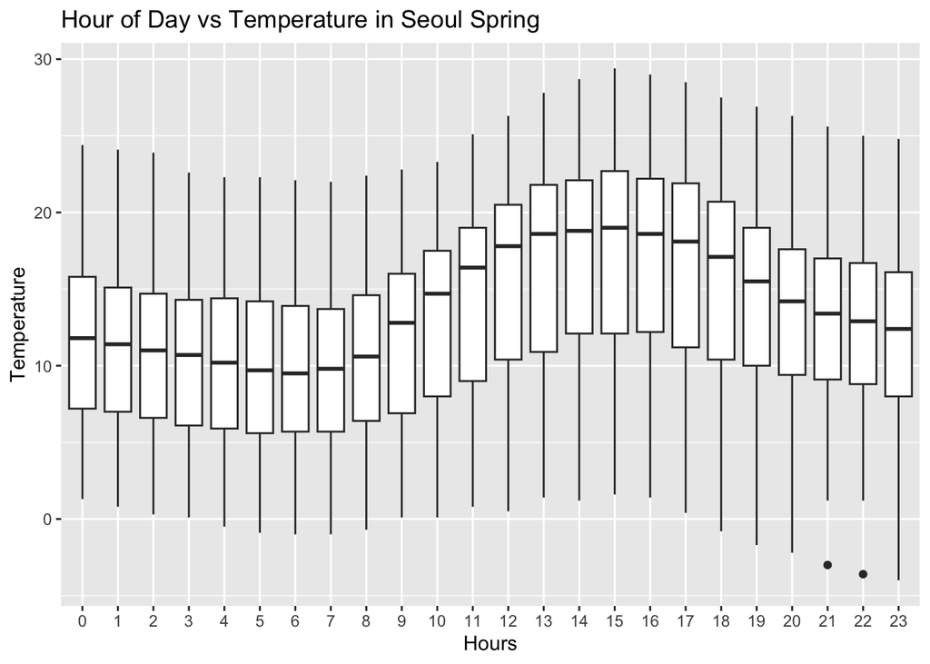

```r
# overall temperature
ggplot(seoul_spring_weather_df, aes(x = as.factor(Hour), y = Temperature)) +
  geom_boxplot() +
  ggtitle("Hour of Day vs Temperature in Seoul Spring") +
  xlab("Hours")
```

##### Plot of Each Covariate Quantiles Agaisnt Temperature

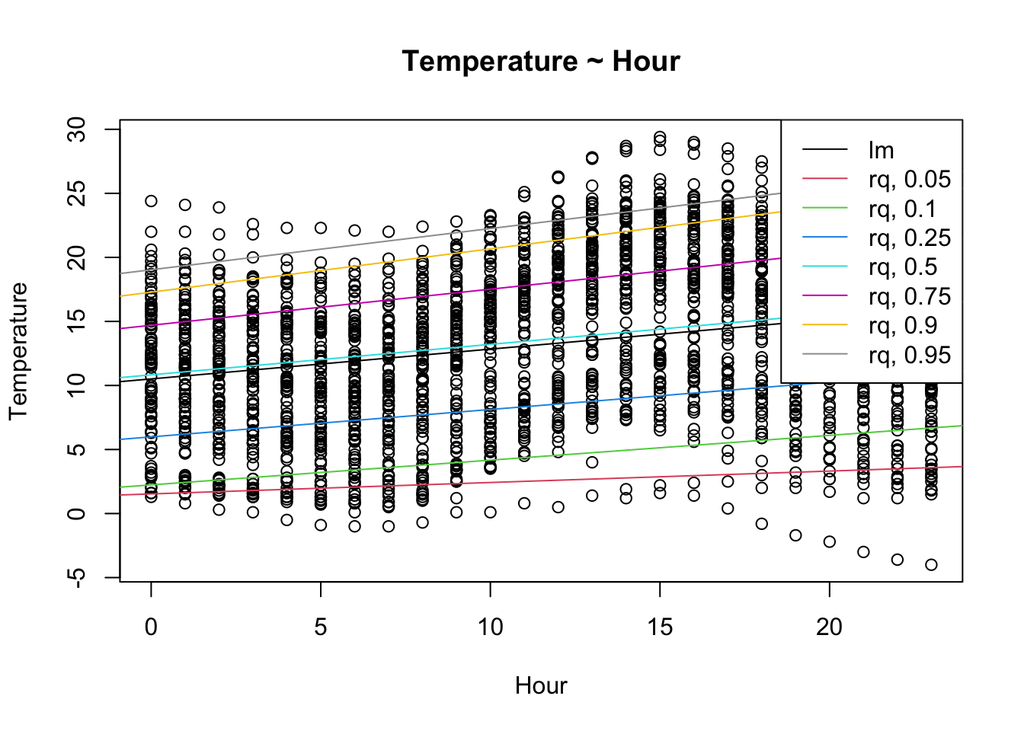

```r
T=c(0.05,0.1,0.25,0.5,0.75,0.9,0.95)
{
plot(Temperature ~ Hour, data = seoul_spring_weather_df, main = "Temperature ~ Hour", ylab= "Temperature", xlab= 'Hour')
abline(lm(Temperature ~ Hour, data = seoul_spring_weather_df), col = 1);

for(t in 1:length(T)){
  abline(rq(Temperature ~ Hour, data = seoul_spring_weather_df, tau=T[t]), col = t+1)
}
legend("topright", legend = c("lm", paste("rq,",as.character(T))), col = c(1:(length(T)+1)),lty = 1)
}
```

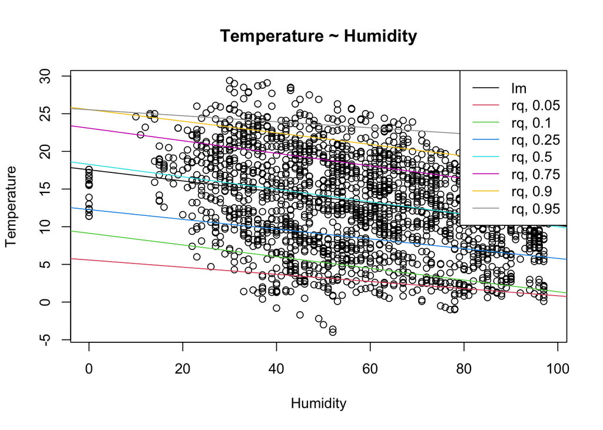

```r
{
plot(Temperature ~ Humidity, data = seoul_spring_weather_df, main = "Temperature ~ Humidity", ylab= "Temperature", xlab= 'Humidity')
abline(lm(Temperature ~ Humidity, data = seoul_spring_weather_df), col = 1);

for(t in 1:length(T)){
  abline(rq(Temperature ~ Humidity, data = seoul_spring_weather_df, tau=T[t]), col = t+1)
}
legend("topright", legend = c("lm", paste("rq,",as.character(T))), col = c(1:(length(T)+1)),lty = 1)
}
```

Negative relationship with humidity. Appears to be slightly more left skewed, consistent variance.

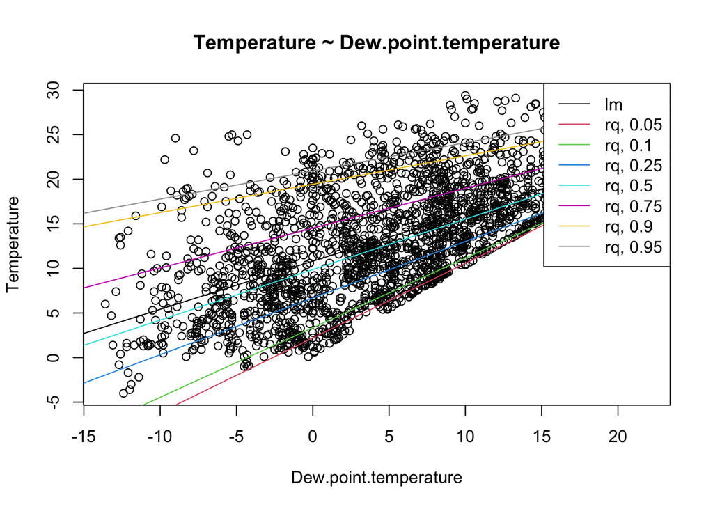

```r
{
plot(Temperature ~ Dew.point.temperature, data = seoul_spring_weather_df, main = "Temperature ~ Dew.point.temperature", ylab= "Temperature", xlab= 'Dew.point.temperature')
abline(lm(Temperature ~ Dew.point.temperature, data = seoul_spring_weather_df), col = 1);

for(t in 1:length(T)){
  abline(rq(Temperature ~ Dew.point.temperature, data = seoul_spring_weather_df, tau=T[t]), col = t+1)
}
legend("topright", legend = c("lm", paste("rq,",as.character(T))), col = c(1:(length(T)+1)),lty = 1)
}
```

Positive relationship with temperature. Clear threshold at lowest quantile of 0.05. Appears right skewed with decreasing variance as dew point temperature increases. Note: dew point temperature is directly calculated from temperature therefore we would expect to see some of threshold.

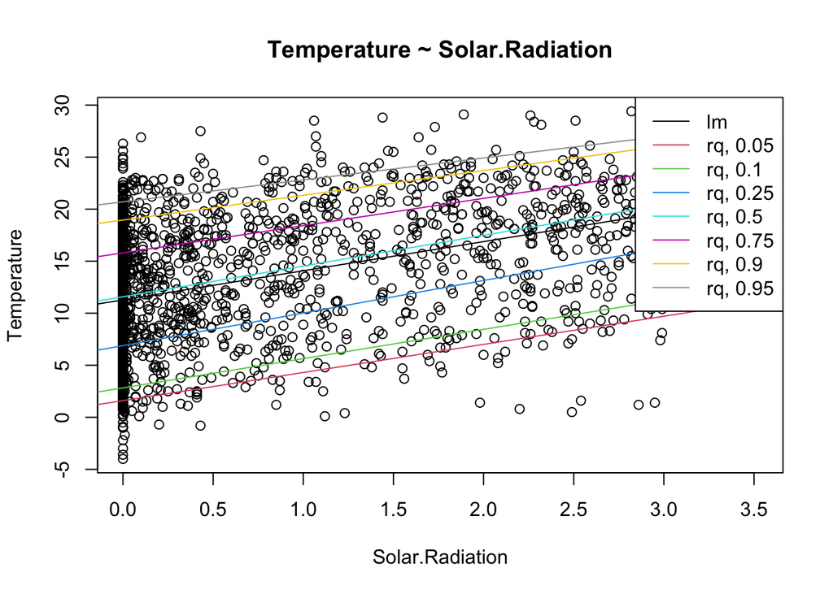

```r
{
plot(Temperature ~ Solar.Radiation, data = seoul_spring_weather_df, main = "Temperature ~ Solar.Radiation", ylab= "Temperature", xlab= 'Solar.Radiation')
abline(lm(Temperature ~ Solar.Radiation, data = seoul_spring_weather_df), col = 1);

for(t in 1:length(T)){
  abline(rq(Temperature ~ Solar.Radiation, data = seoul_spring_weather_df, tau=T[t]), col = t+1)
}
legend("topright", legend = c("lm", paste("rq,",as.character(T))), col = c(1:(length(T)+1)),lty = 1)
}
```

Positive relationship with temperature. Appears symmetrically distributed with light tails., consistent variance. Note: many more data points at lower solar radiation.